# Introduction to Jupyter Notebooks

Author

Isabelle Antaran

This notebook is composed of many *chunks*, containing either python code or formatted text. In this activity you will practice both. Make sure to always run each code chunk once as you work past it.

### Section 2

#### Subsection

*Get in a group of 3-4 people. You should each fill out your own copy of this notebook.*

1. Write the names of your group members below, as a bullet point list.
- Isabelle Antaran
- Nav Anand
- Lizeng Wang
2. Find something that all of you enjoy for fun. Insert a related picture or meme below.

[figure not shown]

3. Everyone decide your comfort level on a scale of 1-10 in python, and your favorite colors from [this](https://matplotlib.org/stable/gallery/color/named_colors.html) list.
- Isabelle Antaran -> 4/10 -> purple
- Nav Anand -> 9/10 -> blue
- Lizeng Wang -> 2/10 -> green

Edit the code below so that it has your names and corresponding comfort levels.

```python
group_data = {
  'names': ["Isabelle", "Nav", "Lizeng"],
  'colors': ["purple", "blue", "green"],
  'comfort': [4, 9, 2]
  }
```

4. Click “Run” on the code chunk below and see the plot that is produced.

(Do not edit the code below!)

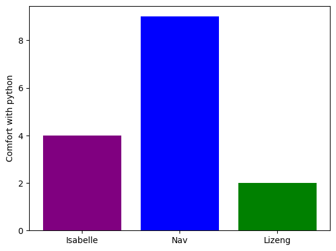

Our comfort levels with python

```python
plt.bar(x = group_data['names'], height = group_data['comfort'], color = group_data['colors'])
plt.ylabel("Comfort with python")
plt.show()
```